# Proyecto R

LUIS DIEGO DEL RÍO SOTO

## **Red de Meteorología y Radiación Solar (REDMET)**

#### **Fuente:** Portal de Datos Abiertos

#### **Última Actualización:** 28 de junio 2023

#### **Apartado:** Datos completos de la Red de Meteorología y Radiación Solar (REDMET) de 2022

#### **Liga:** https://datos.cdmx.gob.mx/dataset/redmet

### **Objetivo**

El objetivo de este reporte es analizar y visualizar los datos recopilados por la Red de Meteorología y Radiación Solar (REDMET) para comprender las tendencias y variaciones en las condiciones meteorológicas y la radiación solar en una ubicación específica.

### **Justificación**

Los datos de la REDMET son esenciales para comprender y anticipar cambios en el clima y la radiación solar, lo que permite tomar decisiones informadas en sectores como la agricultura, la energía renovable y la planificación urbana. El análisis en la herramienta R proporciona informacion clave para la gestión de recursos y la mitigación de riesgos asociados al cambio climático.

### **Diccionario de datos**

- Temperatura (TMP)
- Humedad relativa (RH)
- Dirección del viento (WDR)
- Velocidad del viento (WSP)

### **Breve vistazo de la información**

#### 1.- Parte superior.

```r
#install.packages("ggplot2")
#install.packages("MASS")

redmet <- read.csv("redmet.csv")
head(redmet)
```

```
##        fecha  hora cve_estac     nom_estac  longitud  latitud  RH  TMP WDR WSP
## 1 2022-01-01 01:00       ACO       Acolman -98.91200 19.63550  71  9.9 326 1.5
## 2 2022-01-01 01:00       AJM  Ajusco Medio -99.20774 19.27216 NaN  NaN NaN NaN
## 3 2022-01-01 01:00       AJU        Ajusco -99.16261 19.15429  99  2.9 NaN NaN
## 4 2022-01-01 01:00       BJU Benito Juárez -99.15960 19.37046  55 13.5 166 1.4
## 5 2022-01-01 01:00       CHO        Chalco -98.88609 19.26695  60 11.5 171 0.7
## 6 2022-01-01 01:00       CUA    Cuajimalpa -99.29170 19.36531 NaN  NaN NaN NaN
```

#### 2.- Parte inferior.

```r
tail(redmet)
```

```
##             fecha  hora cve_estac           nom_estac  longitud  latitud  RH
## 245275 2022-12-31 24:00       TAH             Tláhuac -99.01056 19.24646  62
## 245276 2022-12-31 24:00       TLA        Tlalnepantla -99.20460 19.52908  56
## 245277 2022-12-31 24:00       UAX      UAM Xochimilco -99.10363 19.30444  69
## 245278 2022-12-31 24:00       UIZ      UAM Iztapalapa -99.07388 19.36079  71
## 245279 2022-12-31 24:00       VIF Villa de las Flores -99.09659 19.65822  64
## 245280 2022-12-31 24:00       XAL            Xalostoc -99.08240 19.52600 NaN
##         TMP WDR WSP
## 245275  9.9 112 1.4
## 245276 13.3  28 1.5
## 245277 10.8 134 1.7
## 245278 13.4 200 0.6
## 245279 10.6 274 0.2
## 245280  NaN NaN NaN
```

#### **Moda de temperatura durante el año 2022**

```r
  moda<-function(datos){
    return(sort(table(datos),decreasing = T)[1])
  }
 moda(redmet$TMP)
```

```
## 15.2
## 1708
```

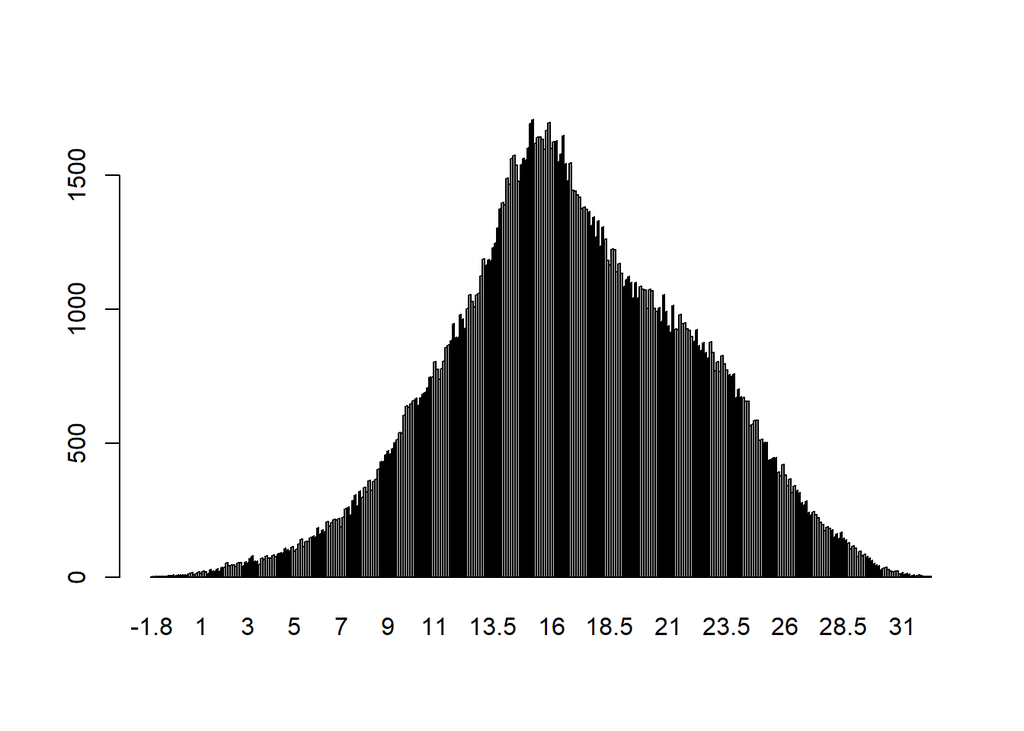

```r
 barplot(table(redmet$TMP))
```

```r
temp<-redmet$TMP[!is.nan(redmet$TMP)]
 median(sort(temp))
```

```
## [1] 16.6
```

#### Quartiles de temperatura durante el año 2022

```r
 quantile(temp)
```

```
##   0%  25%  50%  75% 100%
## -1.8 13.4 16.6 20.5 32.6
```

#### boxplot de temperatura durante el año 2022

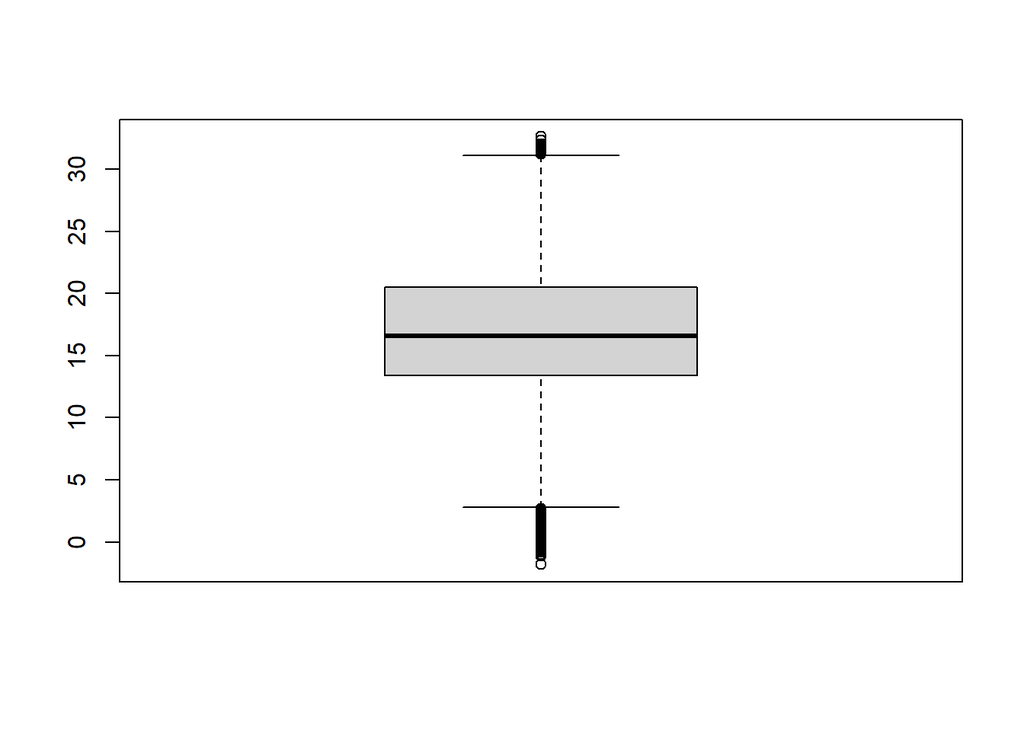

```r
boxplot(temp)
```

```r
summary(temp)
```

```
##    Min. 1st Qu.  Median    Mean 3rd Qu.    Max.
##   -1.80   13.40   16.60   16.85   20.50   32.60
```

#### Moda de humedad relativa durante el año 2022

```r
  moda<-function(datos){
    return(sort(table(datos),decreasing = T)[1])
  }
 moda(redmet$RH)
```

```
##   69
## 3465
```

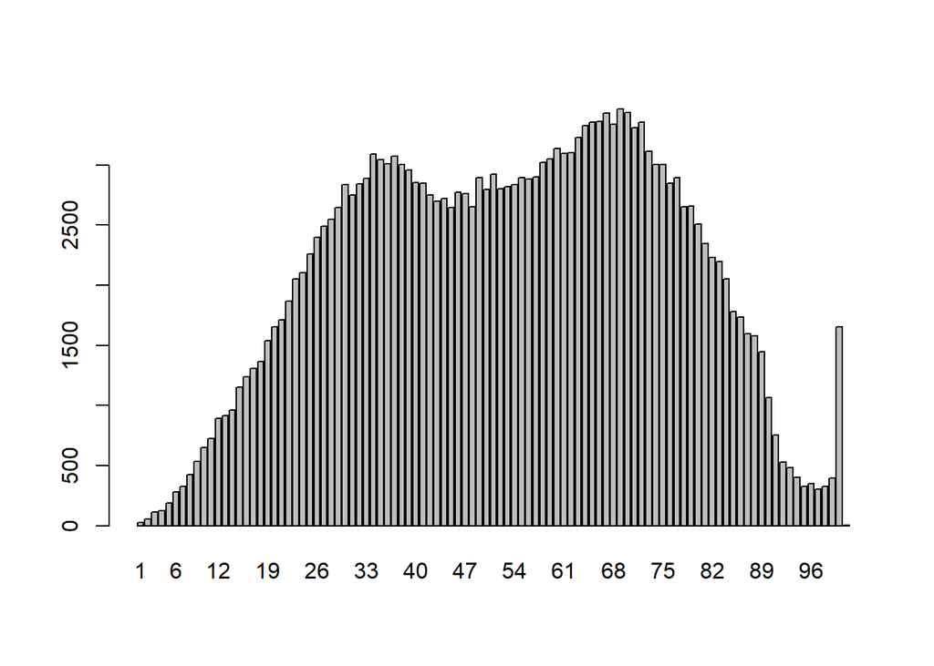

```r
 barplot(table(redmet$RH))
```

```r
humedadRela<-redmet$RH[!is.nan(redmet$RH)]
 median(sort(humedadRela))
```

```
## [1] 54
```

#### Quartiles de humedad relativa durante el año 2022

```r
 quantile(humedadRela)
```

```
##   0%  25%  50%  75% 100%
##    1   36   54   71  101
```

#### boxplot de humedad relativa durante el año 2022

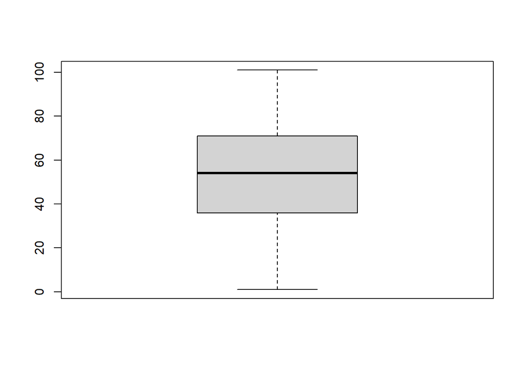

```r
boxplot(humedadRela)
```

```r
summary(humedadRela)
```

```
##    Min. 1st Qu.  Median    Mean 3rd Qu.    Max.
##    1.00   36.00   54.00   53.29   71.00  101.00
```

### **Análisis de temperatura y humedad relativa agrupado por mes**

Con el objetivo de comprender las variaciones mensuales y sus posibles correlaciones. La agrupación mensual de los datos permite una visión más clara de las tendencias a lo largo del año.

```r
Enero      <-redmet[redmet$fecha >='2022-01-01' & redmet$fecha < '2022-02-01',]
febrero    <-redmet[redmet$fecha >='2022-02-01' & redmet$fecha < '2022-03-01',]
marzo      <-redmet[redmet$fecha >='2022-03-01' & redmet$fecha < '2022-04-01',]
abril      <-redmet[redmet$fecha >='2022-04-01' & redmet$fecha < '2022-05-01',]
mayo       <-redmet[redmet$fecha >='2022-05-01' & redmet$fecha < '2022-06-01',]
junio      <-redmet[redmet$fecha >='2022-06-01' & redmet$fecha < '2022-07-01',]
julio      <-redmet[redmet$fecha >='2022-07-01' & redmet$fecha < '2022-08-01',]
agosto     <-redmet[redmet$fecha >='2022-08-01' & redmet$fecha < '2022-09-01',]
septiembre <-redmet[redmet$fecha >='2022-09-01' & redmet$fecha < '2022-10-01',]
octubre    <-redmet[redmet$fecha >='2022-10-01' & redmet$fecha < '2022-11-01',]
noviembre  <-redmet[redmet$fecha >='2022-11-01' & redmet$fecha < '2022-12-01',]
diciembre  <-redmet[redmet$fecha >='2022-12-01' & redmet$fecha < '2023-01-01',]

  meses<-c("Enero","febrero","marzo","abril","mayo","junio","julio","agosto","septiembre","octubre","noviembre","diciembre")
  enero_tem<-Enero$TMP[!is.nan(Enero$TMP)]
  febrero_tem<-febrero$TMP[!is.nan(febrero$TMP)]
  marzo_tem<-marzo$TMP[!is.nan(marzo$TMP)]
  abril_tem<-abril$TMP[!is.nan(abril$TMP)]
  mayo_tem<-mayo$TMP[!is.nan(mayo$TMP)]
  junio_tem<-junio$TMP[!is.nan(junio$TMP)]
  julio_tem<-julio$TMP[!is.nan(julio$TMP)]
  agosto_tem<-agosto$TMP[!is.nan(agosto$TMP)]
  septiembre_tem<-septiembre$TMP[!is.nan(septiembre$TMP)]
  octubre_tem<-octubre$TMP[!is.nan(octubre$TMP)]
  noviembre_tem<-noviembre$TMP[!is.nan(noviembre$TMP)]
  diciembre_tem<-diciembre$TMP[!is.nan(diciembre$TMP)]


tempData<-data.frame(
  meses_tem=meses,
   tem_max=c(
    max(enero_tem),
    max(febrero_tem),
    max(marzo_tem),
    max(abril_tem),
    max(mayo_tem),
    max(junio_tem),
    max(julio_tem),
    max(agosto_tem),
    max(septiembre_tem),
    max(octubre_tem),
    max(noviembre_tem),
    max(diciembre_tem)
  ),
  tem_min=c(
    min(enero_tem),
    min(febrero_tem),
    min(marzo_tem),
    min(abril_tem),
    min(mayo_tem),
    min(junio_tem),
    min(julio_tem),
    min(agosto_tem),
    min(septiembre_tem),
    min(octubre_tem),
    min(noviembre_tem),
    min(diciembre_tem)
  ),
  tem_mean=c(
    mean(enero_tem),
    mean(febrero_tem),
    mean(marzo_tem),
    mean(abril_tem),
    mean(mayo_tem),
    mean(junio_tem),
    mean(julio_tem),
    mean(agosto_tem),
    mean(septiembre_tem),
    mean(octubre_tem),
    mean(noviembre_tem),
    mean(diciembre_tem)
  ),
  tem_median=c(
    median(enero_tem),
    median(febrero_tem),
    median(marzo_tem),
    median(abril_tem),
    median(mayo_tem),
    median(junio_tem),
    median(julio_tem),
    median(agosto_tem),
    median(septiembre_tem),
    median(octubre_tem),
    median(noviembre_tem),
    median(diciembre_tem)
  )
)
```

#### Temperatura máxima, mínima, media y mediana por mes

```r
tempData
```

```
##     meses_tem tem_max tem_min tem_mean tem_median
## 1       Enero    27.4    -1.1 14.20558      13.90
## 2     febrero    31.1    -0.1 15.41515      15.20
## 3       marzo    31.3    -1.8 17.62434      17.60
## 4       abril    32.0     3.1 19.07972      18.80
## 5        mayo    32.6     2.6 20.21841      20.05
## 6       junio    30.1     4.5 17.63598      17.00
## 7       julio    30.4     4.4 17.91634      17.40
## 8      agosto    28.5     4.3 17.30001      16.80
## 9  septiembre    27.0     4.2 16.58708      16.20
## 10    octubre    28.4     4.0 16.80366      16.40
## 11  noviembre    27.8     0.7 15.91689      15.50
## 12  diciembre    26.8    -0.6 13.50403      13.30
```

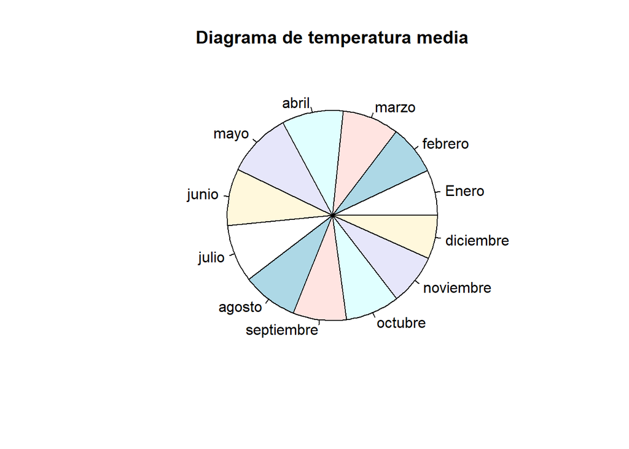

```r
  pie(tempData$tem_mean,labels = tempData$meses_tem, main="Diagrama de temperatura media")
```

```r
temp_mean_min <-sort(tempData$tem_mean,decreasing = F)[1]
temp_mean_max <-sort(tempData$tem_mean,decreasing = T)[1]
temp_mean_min_mes <-tempData[tempData$tem_mean==temp_mean_min,]$meses_tem
temp_mean_max_mes <-tempData[tempData$tem_mean==temp_mean_max,]$meses_tem
temp_mean_max_min  <-data.frame(
   temp_mes=c(temp_mean_min_mes,temp_mean_max_mes),
   temp_mean= c(temp_mean_min,temp_mean_max)
  )
```

#### El mes con mayor temperatura media es **mayo** con 20.21841 y menor es **diciembre** con 13.50403

```r
temp_mean_max_min
```

```
##    temp_mes temp_mean
## 1 diciembre  13.50403
## 2      mayo  20.21841
```

```r
  enero_rh<-Enero$RH[!is.nan(Enero$RH)]
  febrero_rh<-febrero$RH[!is.nan(febrero$RH)]
  marzo_rh<-marzo$RH[!is.nan(marzo$RH)]
  abril_rh<-abril$RH[!is.nan(abril$RH)]
  mayo_rh<-mayo$RH[!is.nan(mayo$RH)]
  junio_rh<-junio$RH[!is.nan(junio$RH)]
  julio_rh<-julio$RH[!is.nan(julio$RH)]
  agosto_rh<-agosto$RH[!is.nan(agosto$RH)]
  septiembre_rh<-septiembre$RH[!is.nan(septiembre$RH)]
  octubre_rh<-octubre$RH[!is.nan(octubre$RH)]
  noviembre_rh<-noviembre$RH[!is.nan(noviembre$RH)]
  diciembre_rh<-diciembre$RH[!is.nan(diciembre$RH)]


 rhData<-data.frame(
   rh_meses=meses,
   rh_max=c(
    max(enero_rh),
    max(febrero_rh),
    max(marzo_rh),
    max(abril_rh),
    max(mayo_rh),
    max(junio_rh),
    max(julio_rh),
    max(agosto_rh),
    max(septiembre_rh),
    max(octubre_rh),
    max(noviembre_rh),
    max(diciembre_rh)
  ),
  rh_min=c(
    min(enero_rh),
    min(febrero_rh),
    min(marzo_rh),
    min(abril_rh),
    min(mayo_rh),
    min(junio_rh),
    min(julio_rh),
    min(agosto_rh),
    min(septiembre_rh),
    min(octubre_rh),
    min(noviembre_rh),
    min(diciembre_rh)
  ),
  rh_mean=c(
    mean(enero_rh),
    mean(febrero_rh),
    mean(marzo_rh),
    mean(abril_rh),
    mean(mayo_rh),
    mean(junio_rh),
    mean(julio_rh),
    mean(agosto_rh),
    mean(septiembre_rh),
    mean(octubre_rh),
    mean(noviembre_rh),
    mean(diciembre_rh)
  ),
  rh_median=c(
    median(enero_rh),
    median(febrero_rh),
    median(marzo_rh),
    median(abril_rh),
    median(mayo_rh),
    median(junio_rh),
    median(julio_rh),
    median(agosto_rh),
    median(septiembre_rh),
    median(octubre_rh),
    median(noviembre_rh),
    median(diciembre_rh)
  )
)
```

#### Humedad relativa máxima, mínima, media y mediana por mes

```r
rhData
```

```
##      rh_meses rh_max rh_min  rh_mean rh_median
## 1       Enero    100      3 51.66302        52
## 2     febrero    100      1 44.40160        42
## 3       marzo    100      1 36.19630        33
## 4       abril    100      4 43.38190        39
## 5        mayo    100      1 38.78537        37
## 6       junio    100      4 58.10552        60
## 7       julio    100      9 61.67720        64
## 8      agosto    100     16 64.63483        68
## 9  septiembre    100     20 64.61644        67
## 10    octubre    101     16 62.21444        65
## 11  noviembre    100      5 58.00941        60
## 12  diciembre    101      1 54.39219        55
```

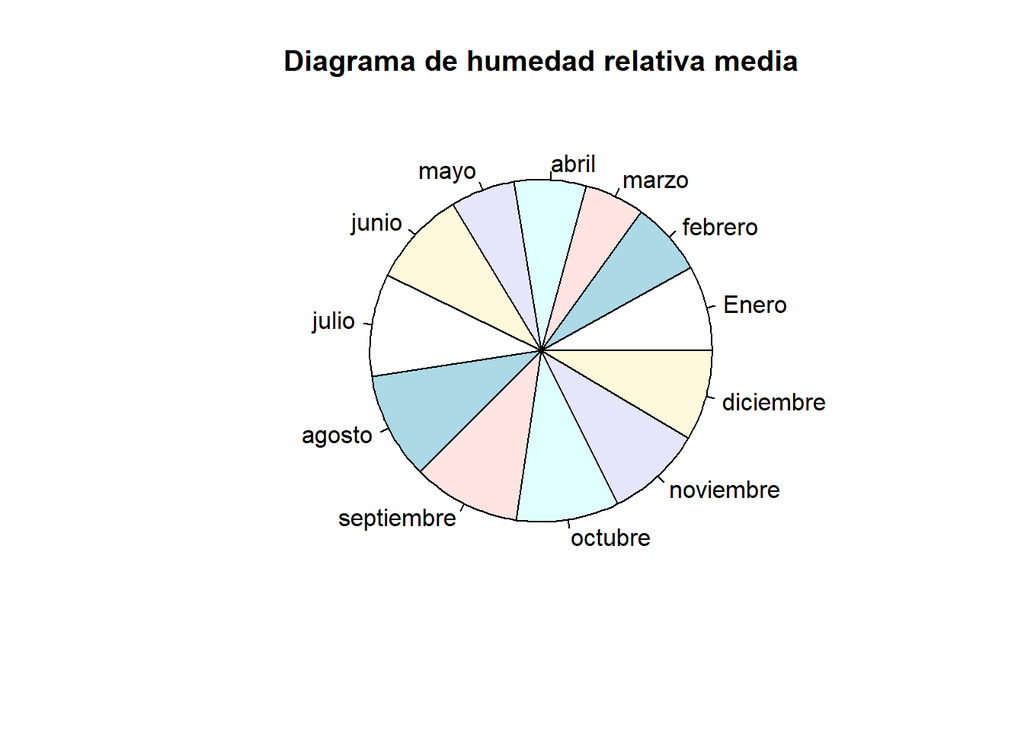

```r
 pie(rhData$rh_mean,labels = rhData$rh_meses, main="Diagrama de humedad relativa media")
```

```r
rh_mean_min <-sort(rhData$rh_mean,decreasing = F)[1]
rh_mean_max <-sort(rhData$rh_mean,decreasing = T)[1]
rh_mean_min_mes <-rhData[rhData$rh_mean==rh_mean_min,]$rh_meses
rh_mean_max_mes <-rhData[rhData$rh_mean==rh_mean_max,]$rh_meses
mean_max_min  <-data.frame(
   rh_mes=c(rh_mean_min_mes,rh_mean_max_mes),
   rh_mean= c(rh_mean_min,rh_mean_max)
  )
```

#### El mes con mayor humedad relativa media es **agosto** con 64.63483 y menor es **marzo** con 36.19630

```r
mean_max_min
```

```
##   rh_mes  rh_mean
## 1  marzo 36.19630
## 2 agosto 64.63483
```

### Gráficas de comparación

#### Se lleva a cabo una comparación detallada entre la temperatura y la humedad relativa durante el mes de enero de 2022. Específicamente en la estación meteorológica UAM Xochimilco, durante el intervalo de 10:00 a 16:00 horas. El análisis se centra en comprender las variaciones y posibles correlaciones entre estos dos parámetros climáticos clave durante ese período y ubicación.

```r
Enero_10_16<-Enero[Enero$hora >='10:00' & Enero$hora<='16:00',]
Enero_10_16_Estac<-Enero_10_16[Enero_10_16$cve_estac =='UAX',]
#plot(Enero_10_16_Estac$TMP,Enero_10_16_Estac$RH,ylab = "Humedad relativa",xlab = #"Temperatura",main = "Análisis comparativo de temperatura y humedad relativa
#durante Enero de 2022.
#Estación UAM Xochimilco (10:00 - 16:00)")
```

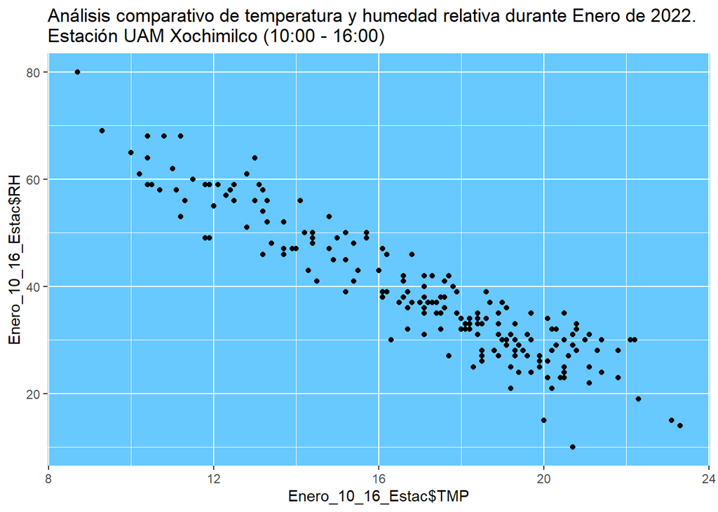

```r
 library(ggplot2)
  df <- data.frame(x = Enero_10_16_Estac$TMP, y = Enero_10_16_Estac$RH)
  ggplot(data = df, aes(x = Enero_10_16_Estac$TMP, y = Enero_10_16_Estac$RH)) +
    geom_point()+
    theme(panel.background = element_rect(fill = "#67c9ff"))+
  labs(title = "Análisis comparativo de temperatura y humedad relativa durante Enero de 2022.
Estación UAM Xochimilco (10:00 - 16:00)")
```

#### En el diagrama se observa que a medida que la temperatura aumenta, la humedad relativa tiende a disminuir.

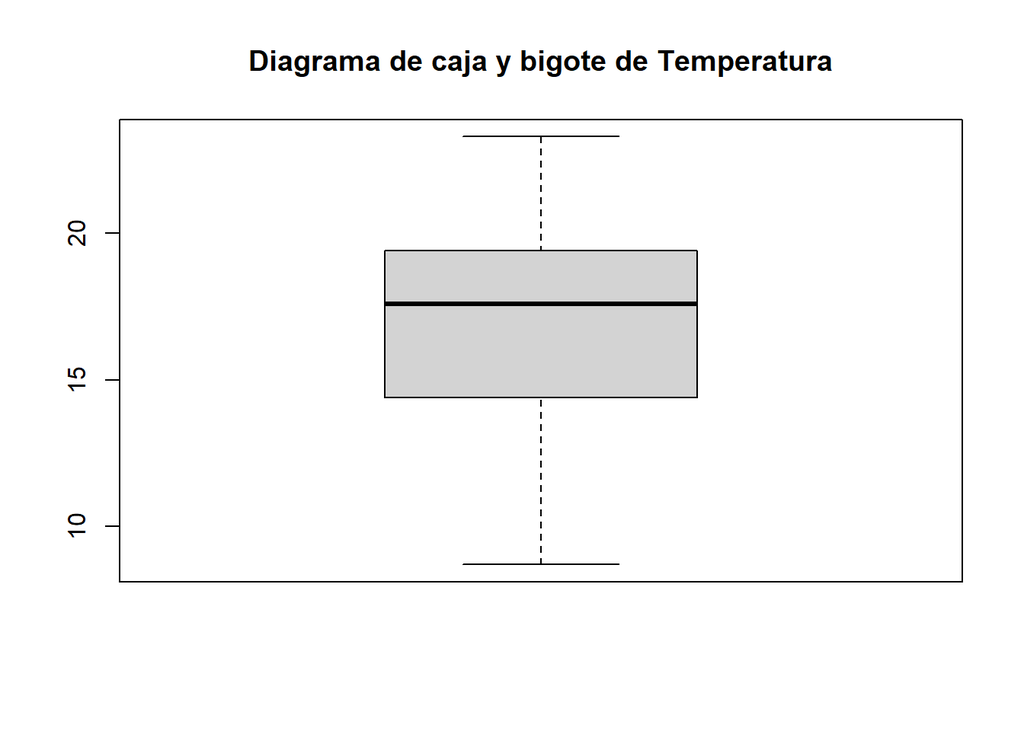

```r
boxplot(Enero_10_16_Estac$TMP, main="Diagrama de caja y bigote de Temperatura")
```

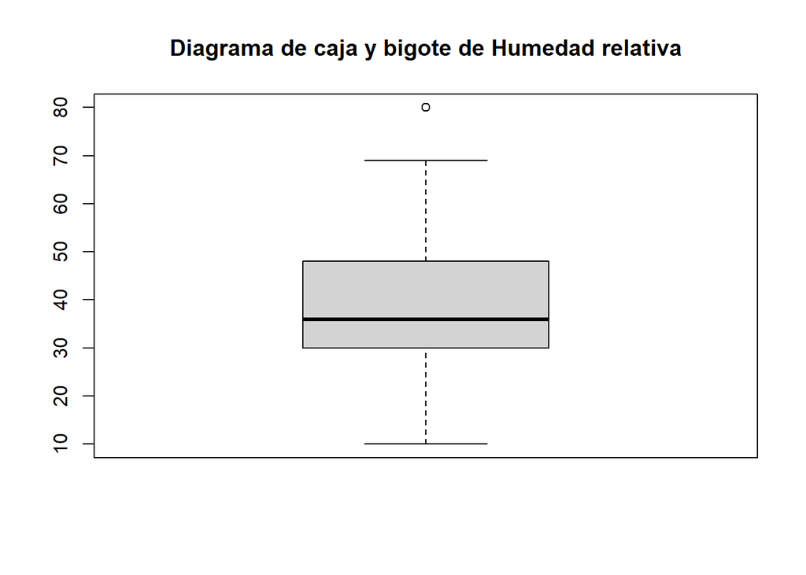

```r
boxplot(Enero_10_16_Estac$RH, main="Diagrama de caja y bigote de Humedad relativa")
```

#### Histograma

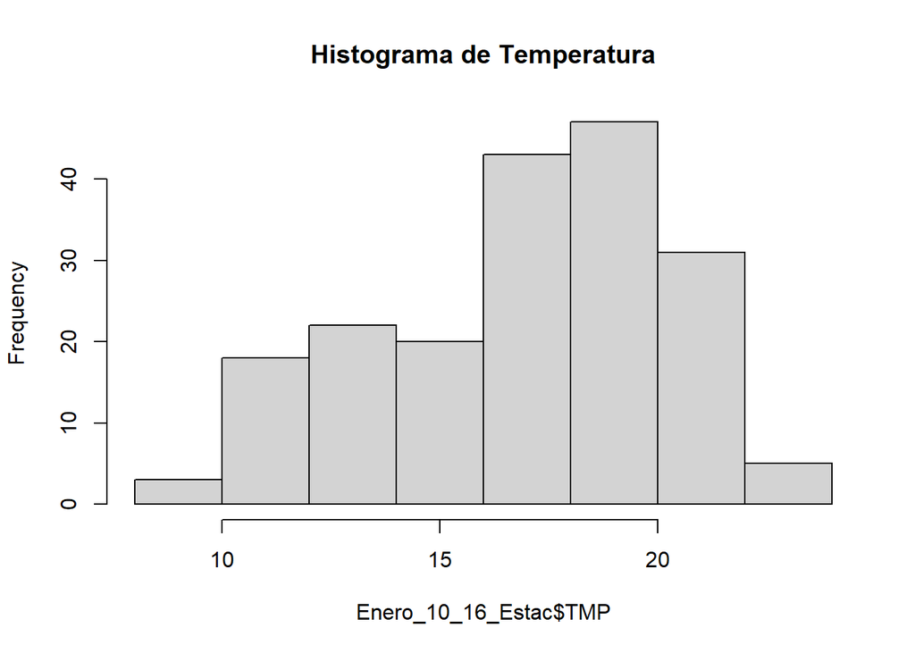

```r
hist(Enero_10_16_Estac$TMP, main="Histograma de Temperatura")
```

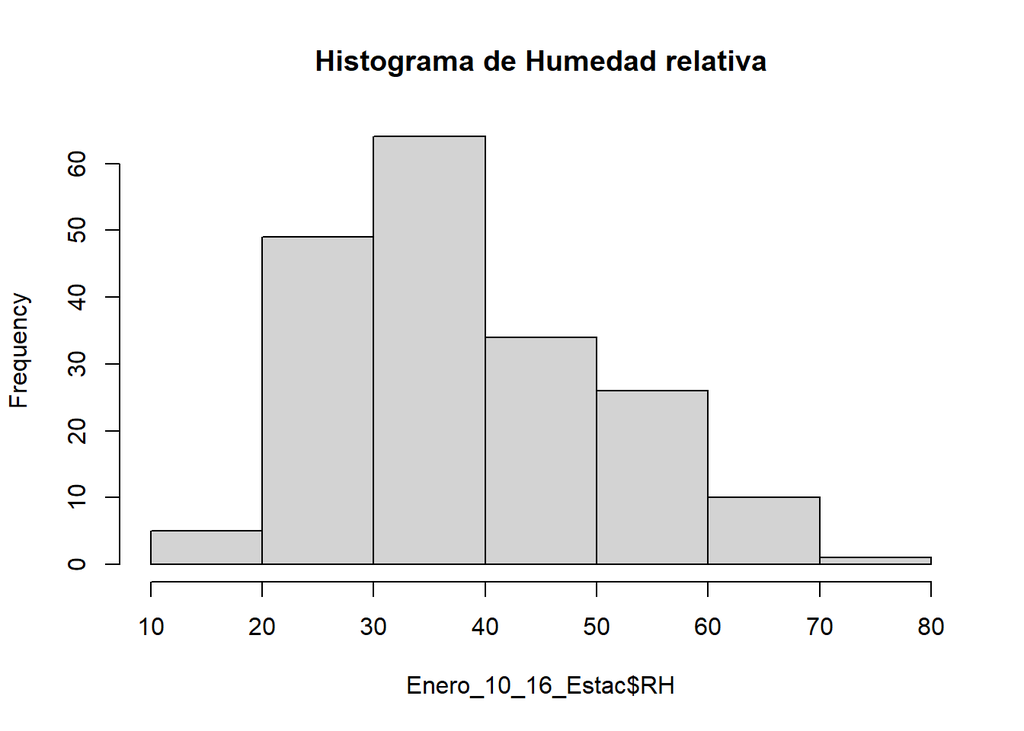

```r
hist(Enero_10_16_Estac$RH, main="Histograma de Humedad relativa")
```